```r
# if (!require("BiocManager", quietly = TRUE))
#     install.packages("BiocManager")
#
# BiocManager::install(version = "3.19")
#
# BiocManager::install("AneuFinder")
# BiocManager::install("BSgenome.Hsapiens.UCSC.hg38")
#
# install.packages ("gplots")
# install.packages("Rcpp")
# install.packages("https://cran.r-project.org/src/contrib/Archive/ReorderCluster/ReorderCluster_2.0.tar.gz", repos=NULL, type="source")
#
# install.packages("R.utils")
# install.packages("dplyr")
```

Q1:

```r
library(AneuFinder)
library(BSgenome.Hsapiens.UCSC.hg38)
setwd("/data/scratch/ha25244/AneuFinder")

# Kuramochi_E10
Aneufinder(
  inputfolder = "Kuramochi_E10/",
  outputfolder = "Kuramochi_E10/Aneufinder_output/",
  assembly = 'hg38',
  numCPU = 2,
  binsizes = 1e6,
  blacklist = "hg38-blacklist.v2.bed",
  correction.method = 'GC',
  GC.BSgenome = BSgenome.Hsapiens.UCSC.hg38,
  refine.breakpoints = FALSE,
  method = 'edivisive',
  chromosomes = c("1","2","3","4","5","6","7","8","9","10","11","12","13","14","15","16","17","18","19","20","21","22","X")
)
```

```
## Setting up parallel execution with 2 CPUs ...
```

```
##  0.23s
```

```
## Obtaining chromosome length information from file Kuramochi_E10//SM200303_4_005.bam ... 0.03s
## ==> Making bins:
## Making fixed-width bins for bin size 1e+06 ... 0.13s
## ==| Finished making bins.
## Binning the data ... 6.68s
## GC correction ... 0.06s
## Running edivisive ... 0.08s
## Finding breakpoint hotspots ... 200.8s
## Plotting genomewide heatmaps ... 0.06s
## Plotting chromosome heatmaps ... 0.06s
## Exporting browser files ... 0.06s
## Making profile and distribution plots ... 0.05s
## Plotting karyograms ... 0.05s
## ==> Total time spent: 208s <==
```

```r
# Kuramochi_C8
Aneufinder(
  inputfolder = "Kuramochi_C8/",
  outputfolder = "Kuramochi_C8/Aneufinder_output/",
  assembly = 'hg38',
  numCPU = 2,
  binsizes = 1e6,
  blacklist = "hg38-blacklist.v2.bed",
  correction.method = 'GC',
  GC.BSgenome = BSgenome.Hsapiens.UCSC.hg38,
  refine.breakpoints = FALSE,
  method = 'edivisive',
  chromosomes = c("1","2","3","4","5","6","7","8","9","10","11","12","13","14","15","16","17","18","19","20","21","22","X")
)
```

```
## Setting up parallel execution with 2 CPUs ... 0.29s
## Obtaining chromosome length information from file Kuramochi_C8//SM200303_4_003.bam ... 0.03s
## ==> Making bins:
## Making fixed-width bins for bin size 1e+06 ... 0.04s
## ==| Finished making bins.
## Binning the data ... 6.74s
## GC correction ... 0.06s
## Running edivisive ... 0.09s
## Finding breakpoint hotspots ... 209.37s
## Plotting genomewide heatmaps ... 0.06s
## Plotting chromosome heatmaps ... 0.06s
## Exporting browser files ... 0.06s
## Making profile and distribution plots ... 0.05s
## Plotting karyograms ... 0.06s
## ==> Total time spent: 217s <==
```

```r
#Snu119_A12
Aneufinder(
  inputfolder = "Snu119_A12/",
  outputfolder = "Snu119_A12/Aneufinder_output/",
  assembly = 'hg38',
  numCPU = 2,
  binsizes = 1e6,
  blacklist = "hg38-blacklist.v2.bed",
  correction.method = 'GC',
  GC.BSgenome = BSgenome.Hsapiens.UCSC.hg38,
  refine.breakpoints = FALSE,
  method = 'edivisive',
  chromosomes = c("1","2","3","4","5","6","7","8","9","10","11","12","13","14","15","16","17","18","19","20","21","22","X")
)
```

```
## Setting up parallel execution with 2 CPUs ... 0.32s
## Obtaining chromosome length information from file Snu119_A12//SM200303_4_009.bam ... 0.02s
## ==> Making bins:
## Making fixed-width bins for bin size 1e+06 ... 0.04s
## ==| Finished making bins.
## Binning the data ... 6.66s
## GC correction ... 0.06s
## Running edivisive ... 0.09s
## Finding breakpoint hotspots ... 210.81s
## Plotting genomewide heatmaps ... 0.06s
## Plotting chromosome heatmaps ... 0.06s
## Exporting browser files ... 0.06s
## Making profile and distribution plots ... 0.06s
## Plotting karyograms ... 0.06s
## ==> Total time spent: 218s <==
```

```r
#Snu119_F12
Aneufinder(
  inputfolder = "Snu119_F12/",
  outputfolder = "Snu119_F12/Aneufinder_output/",
  assembly = 'hg38',
  numCPU = 2,
  binsizes = 1e6,
  blacklist = "hg38-blacklist.v2.bed",
  correction.method = 'GC',
  GC.BSgenome = BSgenome.Hsapiens.UCSC.hg38,
  refine.breakpoints = FALSE,
  method = 'edivisive',
  chromosomes = c("1","2","3","4","5","6","7","8","9","10","11","12","13","14","15","16","17","18","19","20","21","22","X")
)
```

```
## Setting up parallel execution with 2 CPUs ... 0.3s
## Obtaining chromosome length information from file Snu119_F12//SM200303_4_012.bam ... 0.03s
## ==> Making bins:
## Making fixed-width bins for bin size 1e+06 ... 0.04s
## ==| Finished making bins.
## Binning the data ... 6.61s
## GC correction ... 0.06s
## Running edivisive ... 0.09s
## Finding breakpoint hotspots ... 195.32s
## Plotting genomewide heatmaps ... 0.06s
## Plotting chromosome heatmaps ... 0.06s
## Exporting browser files ... 0.07s
## Making profile and distribution plots ... 0.06s
## Plotting karyograms ... 0.06s
## ==> Total time spent: 203s <==
```

IN HPC: [ha25244@login-01 AneuFinder]$ cd Kuramochi_C8/ [ha25244@login-01 Kuramochi_C8]$ mkdir -p bad_data [ha25244@login-01 Kuramochi_C8]$ mv SM200303_4_088.bam* bad_data/

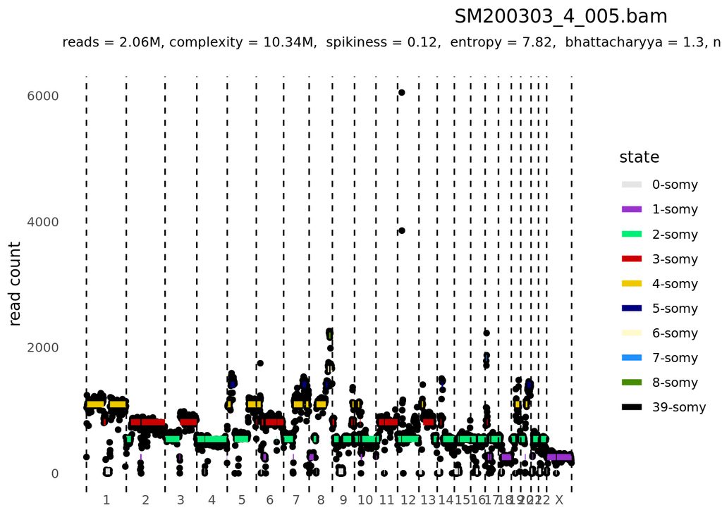

```r
files_E10 = list.files('Kuramochi_E10/Aneufinder_output/MODELS/method-edivisive/', full.names=TRUE)
models_E10 = loadFromFiles(files_E10)
plot(models_E10[[1]], type='profile')
```

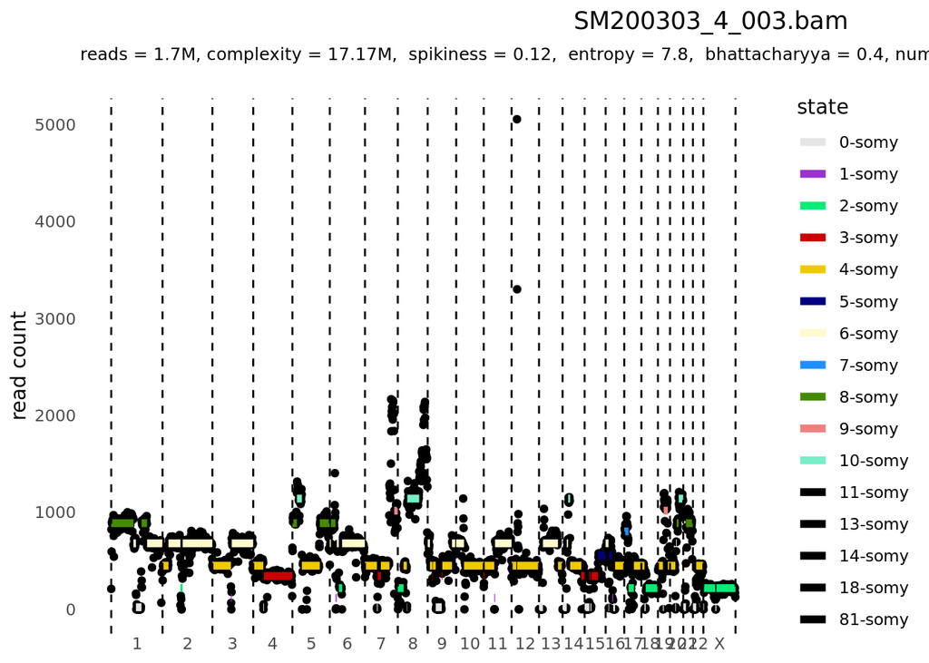

```r
files_C8 = list.files('Kuramochi_C8/Aneufinder_output/MODELS/method-edivisive/', full.names=TRUE)
models_C8 = loadFromFiles(files_C8)
plot(models_C8[[1]], type='profile')
```

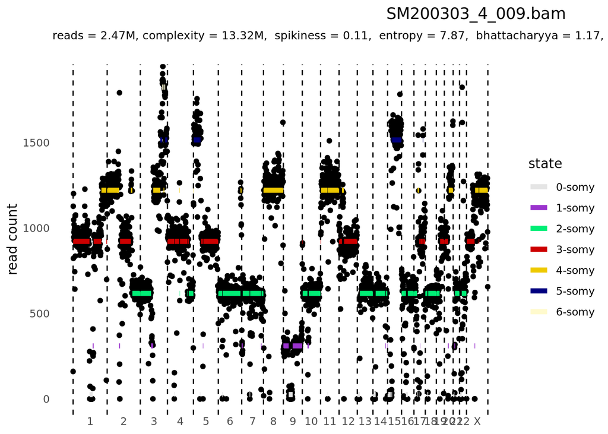

```r
files_A12 = list.files('Snu119_A12/Aneufinder_output/MODELS/method-edivisive/', full.names=TRUE)
models_A12 = loadFromFiles(files_A12)
plot(models_A12[[1]], type='profile')
```

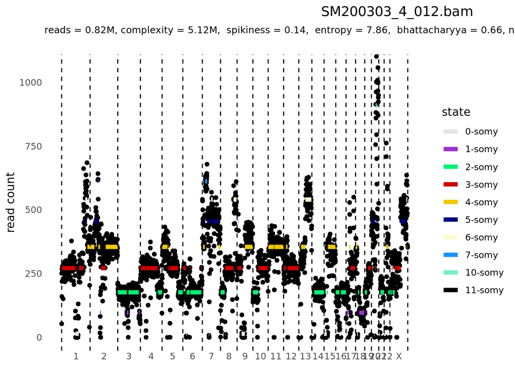

```r
files_F12 = list.files('Snu119_F12/Aneufinder_output/MODELS/method-edivisive/', full.names=TRUE)
models_F12 = loadFromFiles(files_F12)
plot(models_F12[[1]], type='profile')
```

Q2:

```r
#Identifiable:Whole-chromosome aneuploidies,large-scale segmental gains/losses(CNAs) and the precise location of genomic breakpoints.
#Non-identifiable:
# Point Mutations (SNVs):The sequencing depth is too shallow to call individual base-pair changes.
# Balanced Rearrangements (Inversions/Translocations):These do not change the total amount of DNA.(AneuFinder detects changes based on Read Depth (quantity), which remains constant here).
# Small Indels: These are smaller than the analysis bin size (Mb) and are filtered out as background noise.
```

Q3:

```r
load_scdnaseq_dataset <- function(filepath) {
  # Initialize a list to store CNA segment records
  cna_segment_records <- list()

  # Regular expression to gather cell_id (no named capture groups in R's regex)
  cell_id_pattern <- "\\s(\\w+)\\.bam"

  # Read the file line by line
  lines <- readLines(filepath)

  # Initialize cell_id variable
  cell_id <- NA

  for (line in lines) {
    # Check if line has cell metadata
    if (startsWith(line, "track")) {
      # Extract the cell_id using the regular expression
      match <- regexpr(cell_id_pattern, line, perl = TRUE)
      if (match > 0) {
        # Extract the matched cell_id
        cell_id <- regmatches(line, regexpr(cell_id_pattern, line, perl = TRUE))
        # Remove leading space and ".bam"
        cell_id <- gsub("^\\s|\\.bam$", "", cell_id)
      }
    }

    # Check if the line corresponds to a CNA segment
    else if (startsWith(line, "chr")) {
      # Split the line into values
      line_values <- unlist(strsplit(line, "\t"))

      # Extract values from the line
      chrom <- line_values[1]
      start <- as.integer(line_values[2])
      end <- as.integer(line_values[3])
      copy_number <- as.integer(gsub("-somy", "", line_values[4]))

      # Convert RGB values to hex color
      rgb_values <- as.integer(unlist(strsplit(line_values[9], ",")))
      color <- sprintf("#%02x%02x%02x", rgb_values[1], rgb_values[2], rgb_values[3])

      # Append the CNA segment record to the list
      cna_segment_records <- append(cna_segment_records, list(data.frame(
        cell_id = cell_id,
        chrom = chrom,
        start = start,
        end = end,
        copy_number = copy_number,
        color = color,
        stringsAsFactors = FALSE
      )))
    }
  }

  # Combine the list of data frames into a single data frame
  cna_segments_df <- do.call(rbind, cna_segment_records)

  return(cna_segments_df)
}
```

```r
library(R.utils)
library(dplyr)
```

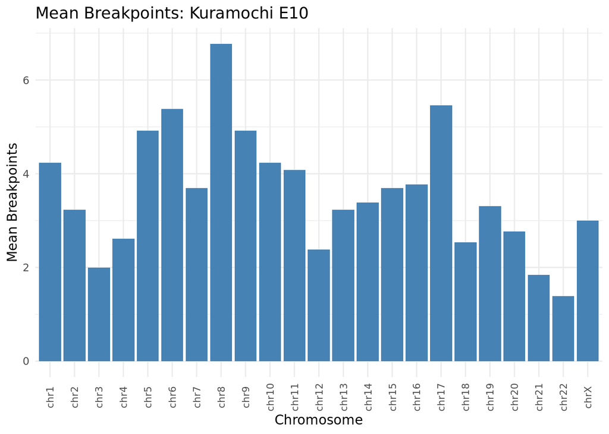

```r
library(ggplot2)

target_order <- c(paste0("chr", 1:22), "chrX", "chrY")

# --- Kuramochi E10 ---
gz_file_E10 <- "Kuramochi_E10/Aneufinder_output/BROWSERFILES/method-edivisive/binsize_1e+06_stepsize_1e+06_CNV.bed.gz"
gunzip(gz_file_E10, remove = FALSE, overwrite = TRUE)
cna_segments_E10 <- load_scdnaseq_dataset(gz_file_E10)

br_summary_E10 <- cna_segments_E10 %>%
  group_by(cell_id, chrom) %>%
  summarise(n_breakpoints = n() - 1, .groups = 'drop')


br_summary_E10$chrom <- factor(br_summary_E10$chrom, levels = target_order)

ggplot(br_summary_E10 %>% filter(!is.na(chrom)), aes(x = chrom, y = n_breakpoints)) +
  geom_bar(stat = "summary", fun = "mean", fill = "steelblue") +
  theme_minimal() +
  labs(title = "Mean Breakpoints: Kuramochi E10", x = "Chromosome", y = "Mean Breakpoints") +
  theme(axis.text.x = element_text(angle = 90, vjust = 0.5, size = 8))
```

```r
avg_per_chrom_E10 <- mean(br_summary_E10$n_breakpoints)
avg_per_cell_E10 <- mean((br_summary_E10 %>% group_by(cell_id) %>% summarise(total = sum(n_breakpoints)))$total)
cat("--- Kuramochi E10 Results ---\nAvg/Chrom:", avg_per_chrom_E10, "| Avg/Cell:", avg_per_cell_E10, "\n\n")
```

```
## --- Kuramochi E10 Results ---
## Avg/Chrom: 3.602007 | Avg/Cell: 82.84615
```

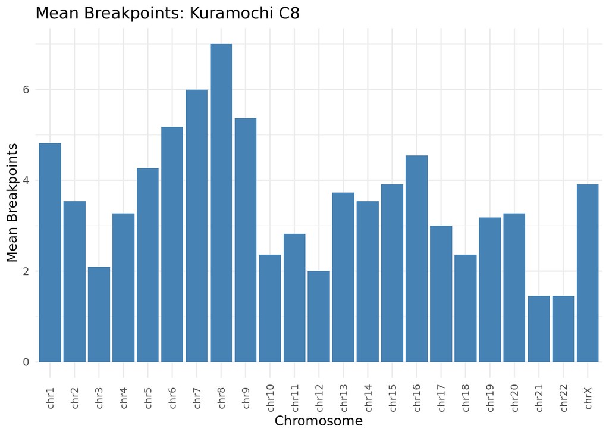

```r
# --- Kuramochi C8 ---
gz_file_C8 <- "Kuramochi_C8/Aneufinder_output/BROWSERFILES/method-edivisive/binsize_1e+06_stepsize_1e+06_CNV.bed.gz"
gunzip(gz_file_C8, remove = FALSE, overwrite = TRUE)
cna_segments_C8 <- load_scdnaseq_dataset(gz_file_C8)

br_summary_C8 <- cna_segments_C8 %>%
  group_by(cell_id, chrom) %>%
  summarise(n_breakpoints = n() - 1, .groups = 'drop')

br_summary_C8$chrom <- factor(br_summary_C8$chrom, levels = target_order)

ggplot(br_summary_C8 %>% filter(!is.na(chrom)), aes(x = chrom, y = n_breakpoints)) +
  geom_bar(stat = "summary", fun = "mean", fill = "steelblue") +
  theme_minimal() +
  labs(title = "Mean Breakpoints: Kuramochi C8", x = "Chromosome", y = "Mean Breakpoints") +
  theme(axis.text.x = element_text(angle = 90, vjust = 0.5, size = 8))
```

```r
avg_per_chrom_C8 <- mean(br_summary_C8$n_breakpoints)
avg_per_cell_C8 <- mean((br_summary_C8 %>% group_by(cell_id) %>% summarise(total = sum(n_breakpoints)))$total)
cat("--- Kuramochi C8 Results ---\nAvg/Chrom:", avg_per_chrom_C8, "| Avg/Cell:", avg_per_cell_C8, "\n\n")
```

```
## --- Kuramochi C8 Results ---
## Avg/Chrom: 3.612648 | Avg/Cell: 83.09091
```

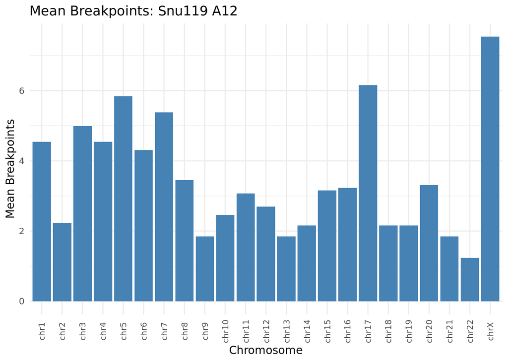

```r
# --- Snu119 A12 ---
gz_file_A12 <- "Snu119_A12/Aneufinder_output/BROWSERFILES/method-edivisive/binsize_1e+06_stepsize_1e+06_CNV.bed.gz"
gunzip(gz_file_A12, remove = FALSE, overwrite = TRUE)
cna_segments_A12 <- load_scdnaseq_dataset(gz_file_A12)

br_summary_A12 <- cna_segments_A12 %>%
  group_by(cell_id, chrom) %>%
  summarise(n_breakpoints = n() - 1, .groups = 'drop')

br_summary_A12$chrom <- factor(br_summary_A12$chrom, levels = target_order)

ggplot(br_summary_A12 %>% filter(!is.na(chrom)), aes(x = chrom, y = n_breakpoints)) +
  geom_bar(stat = "summary", fun = "mean", fill = "steelblue") +
  theme_minimal() +
  labs(title = "Mean Breakpoints: Snu119 A12", x = "Chromosome", y = "Mean Breakpoints") +
  theme(axis.text.x = element_text(angle = 90, vjust = 0.5, size = 8))
```

```r
avg_per_chrom_A12 <- mean(br_summary_A12$n_breakpoints)
avg_per_cell_A12 <- mean((br_summary_A12 %>% group_by(cell_id) %>% summarise(total = sum(n_breakpoints)))$total)
cat("--- Snu119 A12 Results ---\nAvg/Chrom:", avg_per_chrom_A12, "| Avg/Cell:", avg_per_cell_A12, "\n\n")
```

```
## --- Snu119 A12 Results ---
## Avg/Chrom: 3.48495 | Avg/Cell: 80.15385
```

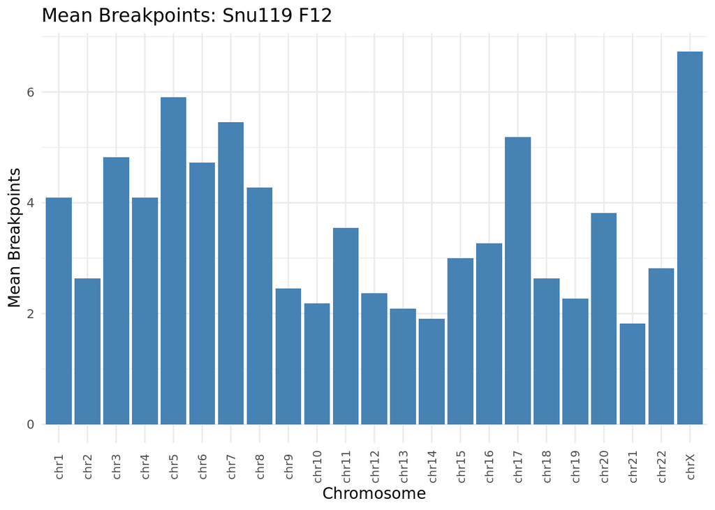

```
## --- Snu119 F12 Results ---
## Avg/Chrom: 3.56917 | Avg/Cell: 82.09091
```

```r
# --- Snu119 F12 ---
gz_file_F12 <- "Snu119_F12/Aneufinder_output/BROWSERFILES/method-edivisive/binsize_1e+06_stepsize_1e+06_CNV.bed.gz"

try({
  gunzip(gz_file_F12, remove = FALSE, overwrite = TRUE)
  cna_segments_F12 <- load_scdnaseq_dataset(gz_file_F12)

  br_summary_F12 <- cna_segments_F12 %>%
    group_by(cell_id, chrom) %>%
    summarise(n_breakpoints = n() - 1, .groups = 'drop')

  br_summary_F12$chrom <- factor(br_summary_F12$chrom, levels = target_order)

  print(ggplot(br_summary_F12 %>% filter(!is.na(chrom)), aes(x = chrom, y = n_breakpoints)) +
    geom_bar(stat = "summary", fun = "mean", fill = "steelblue") +
    theme_minimal() +
    labs(title = "Mean Breakpoints: Snu119 F12", x = "Chromosome", y = "Mean Breakpoints") +
    theme(axis.text.x = element_text(angle = 90, vjust = 0.5, size = 8)))

  avg_per_chrom_F12 <- mean(br_summary_F12$n_breakpoints)
  avg_per_cell_F12 <- mean((br_summary_F12 %>% group_by(cell_id) %>% summarise(total = sum(n_breakpoints)))$total)
  cat("--- Snu119 F12 Results ---\nAvg/Chrom:", avg_per_chrom_F12, "| Avg/Cell:", avg_per_cell_F12, "\n\n")
})
```

Per Chromosome Calculation: The average number of genomic breakpoints per chromosome across the analyzed clones varies between 3.48 and 3.61.

Per Cell Calculation: The mean total number of breakpoints per cell (representing the entire genome) ranges from 80.15 (for Snu119 A12) to 83.09 (for Kuramochi C8).

Copy Number Alterations (CNAs) are not evenly distributed across the chromosomes.

As demonstrated in the generated bar charts, some chromosomes exhibit significantly higher mean breakpoint frequencies.( like chromosome 8 in Kuramochi) If the distribution were even, all bars would maintain a uniform height; however, the observed variation in bar heights clearly indicates the presence of genomic instability “hotspots” within these ovarian cancer cell lines.

Q4:

```r
# برای لاین Kuramochi (ترکیب داده‌های دو کلون)
kuramochi_all <- rbind(cna_segments_E10, cna_segments_C8)
range_kuramochi <- range((kuramochi_all$end - kuramochi_all$start) / 1e6)

# برای لاین Snu119
snu119_all <- rbind(cna_segments_A12, cna_segments_F12)
range_snu119 <- range((snu119_all$end - snu119_all$start) / 1e6)

print(range_kuramochi)
```

```
## [1]   2 147
```

```r
print(range_snu119)
```

```
## [1]   2 157
```

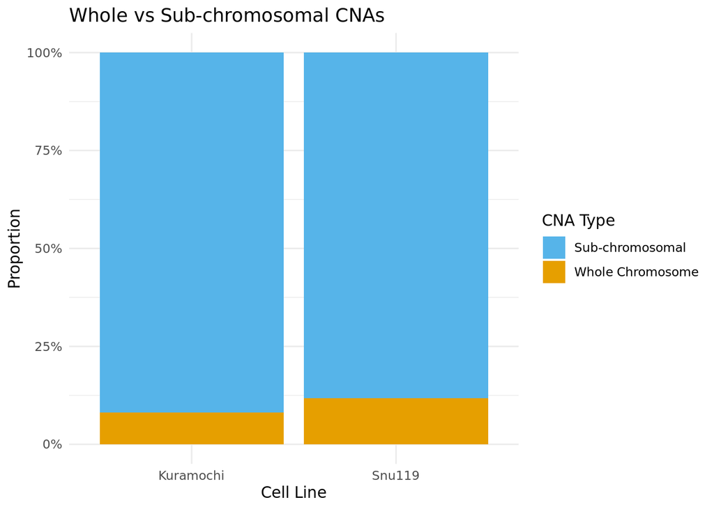

```r
get_cna_types <- function(df) {
  df %>%
    filter(copy_number != 2) %>%
    group_by(cell_id, chrom) %>%
    summarise(n_segments = n(), .groups = 'drop') %>%
    mutate(type = ifelse(n_segments == 1, "Whole Chromosome", "Sub-chromosomal"))
}


types_E10 <- get_cna_types(cna_segments_E10)
types_C8  <- get_cna_types(cna_segments_C8)
types_A12 <- get_cna_types(cna_segments_A12)
types_F12 <- get_cna_types(cna_segments_F12)


combined_types <- rbind(
  mutate(rbind(types_E10, types_C8), Line = "Kuramochi"),
  mutate(rbind(types_A12, types_F12), Line = "Snu119")
)


ggplot(combined_types, aes(x = Line, fill = type)) +
  geom_bar(position = "fill") +
  scale_y_continuous(labels = scales::percent) +
  scale_fill_manual(values = c("Sub-chromosomal" = "#56B4E9", "Whole Chromosome" = "#E69F00")) +
  theme_minimal() +
  labs(title = "Whole vs Sub-chromosomal CNAs",
       x = "Cell Line", y = "Proportion", fill = "CNA Type")
```

CNA Size Range Analysis: Kuramochi Line: The genomic alterations in this line exhibit a size range from 2 Mb to 147 Mb. Snu119 Line: The alterations in this line span a range from 2 Mb to 157 Mb.

***The wide range of sizes indicates that alterations occur both at sub-chromosomal level and at a large-scale (whole-chromosome) level.

***The majority of alterations in both cell lines involve fragmentation of chromosomal arms, indicating pronounced structural instability.

***Whole-chromosome alterations account for only a very small proportion of the changes.

conclusion: The predominance of sub-chromosomal alterations over whole-chromosome changes in these samples indicates that the cells are not only gaining or losing entire chromosomes, but are also extensively breaking down and fragmenting the chromosomes they already contain.